# Optimal Treatment Analysis

## Outcome Variable

**Outcome Variable:** whz

## Predictor Variables

**Intervention Variable:** rain_quartile

**Adjustment Set:**

unadjusted

## Stratifying Variables

The analysis was stratified on these variable(s):

- studyid
- country
- agecat

## Data Summary

| studyid | country | agecat | rain_quartile | n_cell | n |
| --- | --- | --- | --- | --- | --- |
| CMC-V-BCS-2002 | India | Birth | 1 | 17 | 86 |
| CMC-V-BCS-2002 | India | Birth | 2 | 22 | 86 |
| CMC-V-BCS-2002 | India | Birth | 3 | 28 | 86 |
| CMC-V-BCS-2002 | India | Birth | 4 | 19 | 86 |
| CMC-V-BCS-2002 | India | 6 months | 1 | 102 | 368 |
| CMC-V-BCS-2002 | India | 6 months | 2 | 109 | 368 |
| CMC-V-BCS-2002 | India | 6 months | 3 | 97 | 368 |
| CMC-V-BCS-2002 | India | 6 months | 4 | 60 | 368 |
| CMC-V-BCS-2002 | India | 24 months | 1 | 87 | 334 |
| CMC-V-BCS-2002 | India | 24 months | 2 | 90 | 334 |
| CMC-V-BCS-2002 | India | 24 months | 3 | 95 | 334 |
| CMC-V-BCS-2002 | India | 24 months | 4 | 62 | 334 |
| CMIN | Bangladesh | Birth | 1 | 4 | 19 |
| CMIN | Bangladesh | Birth | 2 | 5 | 19 |
| CMIN | Bangladesh | Birth | 3 | 5 | 19 |
| CMIN | Bangladesh | Birth | 4 | 5 | 19 |
| CMIN | Bangladesh | 6 months | 1 | 50 | 243 |
| CMIN | Bangladesh | 6 months | 2 | 62 | 243 |
| CMIN | Bangladesh | 6 months | 3 | 70 | 243 |
| CMIN | Bangladesh | 6 months | 4 | 61 | 243 |
| CMIN | Bangladesh | 24 months | 1 | 73 | 225 |
| CMIN | Bangladesh | 24 months | 2 | 64 | 225 |
| CMIN | Bangladesh | 24 months | 3 | 52 | 225 |
| CMIN | Bangladesh | 24 months | 4 | 36 | 225 |
| CONTENT | Peru | Birth | 1 | 0 | 2 |
| CONTENT | Peru | Birth | 2 | 2 | 2 |
| CONTENT | Peru | Birth | 3 | 0 | 2 |
| CONTENT | Peru | Birth | 4 | 0 | 2 |
| CONTENT | Peru | 6 months | 1 | 62 | 215 |
| CONTENT | Peru | 6 months | 2 | 32 | 215 |

[output cut: 238 more lines]

The following strata were considered:

- studyid: CMC-V-BCS-2002, country: India, agecat: 24 months
- studyid: CMC-V-BCS-2002, country: India, agecat: 6 months
- studyid: CMC-V-BCS-2002, country: India, agecat: Birth
- studyid: CMIN, country: Bangladesh, agecat: 24 months
- studyid: CMIN, country: Bangladesh, agecat: 6 months
- studyid: CMIN, country: Bangladesh, agecat: Birth
- studyid: CONTENT, country: Peru, agecat: 24 months
- studyid: CONTENT, country: Peru, agecat: 6 months
- studyid: CONTENT, country: Peru, agecat: Birth
- studyid: EE, country: Pakistan, agecat: 24 months
- studyid: EE, country: Pakistan, agecat: 6 months
- studyid: EE, country: Pakistan, agecat: Birth
- studyid: GMS-Nepal, country: Nepal, agecat: 24 months
- studyid: GMS-Nepal, country: Nepal, agecat: 6 months
- studyid: GMS-Nepal, country: Nepal, agecat: Birth
- studyid: Guatemala BSC, country: Guatemala, agecat: 6 months
- studyid: IRC, country: India, agecat: 24 months
- studyid: IRC, country: India, agecat: 6 months
- studyid: IRC, country: India, agecat: Birth
- studyid: JiVitA-3, country: Bangladesh, agecat: 24 months
- studyid: JiVitA-3, country: Bangladesh, agecat: 6 months
- studyid: JiVitA-3, country: Bangladesh, agecat: Birth
- studyid: JiVitA-4, country: Bangladesh, agecat: 24 months
- studyid: JiVitA-4, country: Bangladesh, agecat: 6 months
- studyid: JiVitA-4, country: Bangladesh, agecat: Birth
- studyid: Keneba, country: Gambia, agecat: 24 months
- studyid: Keneba, country: Gambia, agecat: 6 months
- studyid: Keneba, country: Gambia, agecat: Birth
- studyid: LCNI-5, country: Malawi, agecat: 24 months
- studyid: LCNI-5, country: Malawi, agecat: 6 months
- studyid: MAL-ED, country: Bangladesh, agecat: 24 months
- studyid: MAL-ED, country: Bangladesh, agecat: 6 months
- studyid: MAL-ED, country: Bangladesh, agecat: Birth
- studyid: MAL-ED, country: Brazil, agecat: 24 months
- studyid: MAL-ED, country: Brazil, agecat: 6 months
- studyid: MAL-ED, country: Brazil, agecat: Birth
- studyid: MAL-ED, country: India, agecat: 24 months
- studyid: MAL-ED, country: India, agecat: 6 months
- studyid: MAL-ED, country: India, agecat: Birth
- studyid: MAL-ED, country: Nepal, agecat: 24 months
- studyid: MAL-ED, country: Nepal, agecat: 6 months
- studyid: MAL-ED, country: Nepal, agecat: Birth
- studyid: MAL-ED, country: Peru, agecat: 24 months
- studyid: MAL-ED, country: Peru, agecat: 6 months
- studyid: MAL-ED, country: Peru, agecat: Birth
- studyid: MAL-ED, country: South Africa, agecat: 24 months
- studyid: MAL-ED, country: South Africa, agecat: 6 months
- studyid: MAL-ED, country: South Africa, agecat: Birth
- studyid: MAL-ED, country: Tanzania, agecat: 24 months
- studyid: MAL-ED, country: Tanzania, agecat: 6 months
- studyid: MAL-ED, country: Tanzania, agecat: Birth
- studyid: PROBIT, country: Belarus, agecat: 24 months
- studyid: PROBIT, country: Belarus, agecat: 6 months
- studyid: PROBIT, country: Belarus, agecat: Birth
- studyid: PROVIDE, country: Bangladesh, agecat: 24 months
- studyid: PROVIDE, country: Bangladesh, agecat: 6 months
- studyid: PROVIDE, country: Bangladesh, agecat: Birth
- studyid: ResPak, country: Pakistan, agecat: 6 months
- studyid: ResPak, country: Pakistan, agecat: Birth
- studyid: SAS-CompFeed, country: India, agecat: 6 months
- studyid: SAS-CompFeed, country: India, agecat: Birth
- studyid: SAS-FoodSuppl, country: India, agecat: 6 months
- studyid: TanzaniaChild2, country: Tanzania, agecat: 24 months
- studyid: TanzaniaChild2, country: Tanzania, agecat: 6 months
- studyid: ZVITAMBO, country: Zimbabwe, agecat: 24 months
- studyid: ZVITAMBO, country: Zimbabwe, agecat: 6 months
- studyid: ZVITAMBO, country: Zimbabwe, agecat: Birth

### Dropped Strata

Some strata were dropped due to rare outcomes:

- studyid: CMIN, country: Bangladesh, agecat: Birth
- studyid: CONTENT, country: Peru, agecat: Birth
- studyid: EE, country: Pakistan, agecat: Birth
- studyid: EE, country: Pakistan, agecat: 6 months
- studyid: EE, country: Pakistan, agecat: 24 months
- studyid: GMS-Nepal, country: Nepal, agecat: Birth
- studyid: GMS-Nepal, country: Nepal, agecat: 6 months
- studyid: GMS-Nepal, country: Nepal, agecat: 24 months
- studyid: JiVitA-3, country: Bangladesh, agecat: 24 months
- studyid: PROVIDE, country: Bangladesh, agecat: 24 months
- studyid: ResPak, country: Pakistan, agecat: Birth
- studyid: TanzaniaChild2, country: Tanzania, agecat: 24 months

## Methods Detail

We’re interested in the causal parameters $E[Y_a]$ for all values of $a \in \mathcal{A}$. These parameters represent the mean outcome if, possibly contrary to fact, we intervened to set all units to have $A=a$. Under the randomization and positivity assumptions, these are identified by the statistical parameters $\psi_a=E_W[E_{Y|A,W}(Y|A=a,W)]$. In addition, we’re interested in the mean of $Y$, $E[Y]$ under no intervention (the observed mean). We will estimate these parameters by using SuperLearner to fit the relevant likelihood factors – $E_{Y|A,W}(Y|A=a,W)$ and $p(A=a|W)$, and then updating our likelihood fit using a joint TMLE.

For unadjusted analyses ($W=\{\}$), initial likelihoods were estimated using Lrnr_glm to estimate the simple $E(Y|A)$ and Lrnr_mean to estimate $p(A)$. For adjusted analyses, a small library containing Lrnr_glmnet, Lrnr_xgboost, and Lrnr_mean was used.

Having estimated these parameters, we will then use the delta method to estimate relative risks and attributable risks relative to a prespecified baseline level of $A$.

# Results Detail

## Results Plots

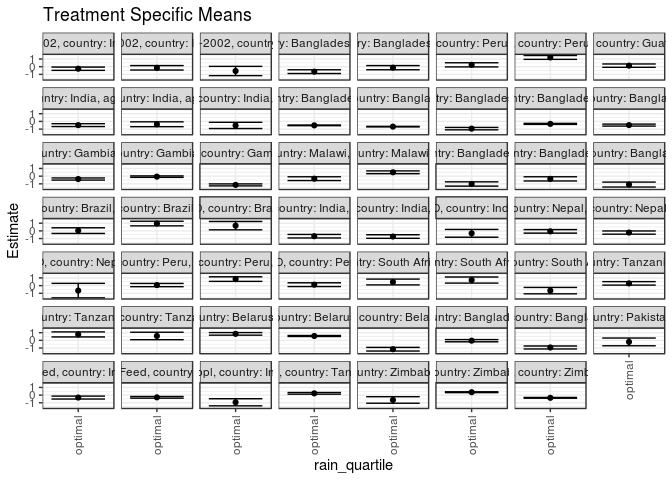

## Results Table

### Parameter: TSM

| studyid | country | agecat | intervention_level | baseline_level | estimate | ci_lower | ci_upper |
| --- | --- | --- | --- | --- | --- | --- | --- |
| CMC-V-BCS-2002 | India | Birth | optimal | observed | -0.5647474 | -1.1695962 | 0.0401015 |
| CMC-V-BCS-2002 | India | 6 months | optimal | observed | -0.1497572 | -0.4394831 | 0.1399686 |
| CMC-V-BCS-2002 | India | 24 months | optimal | observed | -0.2656738 | -0.4798052 | -0.0515423 |
| CMIN | Bangladesh | 6 months | optimal | observed | -0.1319371 | -0.4031163 | 0.1392422 |
| CMIN | Bangladesh | 24 months | optimal | observed | -0.6479734 | -0.8925503 | -0.4033965 |
| CONTENT | Peru | 6 months | optimal | observed | 1.2039588 | 0.9492815 | 1.4586362 |
| CONTENT | Peru | 24 months | optimal | observed | 0.2398807 | -0.0296990 | 0.5094603 |
| Guatemala BSC | Guatemala | 6 months | optimal | observed | 0.1332417 | -0.0848280 | 0.3513113 |
| IRC | India | Birth | optimal | observed | -0.5219235 | -0.9288909 | -0.1149560 |
| IRC | India | 6 months | optimal | observed | -0.3727198 | -0.6869804 | -0.0584592 |
| IRC | India | 24 months | optimal | observed | -0.4851447 | -0.6697556 | -0.3005338 |
| JiVitA-3 | Bangladesh | Birth | optimal | observed | -0.6782799 | -0.7118242 | -0.6447355 |
| JiVitA-3 | Bangladesh | 6 months | optimal | observed | -0.5159057 | -0.5553833 | -0.4764281 |
| JiVitA-4 | Bangladesh | Birth | optimal | observed | -0.4804146 | -0.6130320 | -0.3477973 |
| JiVitA-4 | Bangladesh | 6 months | optimal | observed | -0.3226143 | -0.3861161 | -0.2591125 |
| JiVitA-4 | Bangladesh | 24 months | optimal | observed | -0.9416603 | -1.0961393 | -0.7871813 |
| Keneba | Gambia | Birth | optimal | observed | -1.1398142 | -1.2703498 | -1.0092786 |
| Keneba | Gambia | 6 months | optimal | observed | -0.0653878 | -0.1590107 | 0.0282351 |
| Keneba | Gambia | 24 months | optimal | observed | -0.3779874 | -0.5155496 | -0.2404252 |
| LCNI-5 | Malawi | 6 months | optimal | observed | 0.5018917 | 0.3223857 | 0.6813977 |
| LCNI-5 | Malawi | 24 months | optimal | observed | -0.3293102 | -0.5750361 | -0.0835843 |
| MAL-ED | Bangladesh | Birth | optimal | observed | -1.0956599 | -1.4167343 | -0.7745856 |
| MAL-ED | Bangladesh | 6 months | optimal | observed | -0.3565868 | -0.6295721 | -0.0836015 |
| MAL-ED | Bangladesh | 24 months | optimal | observed | -1.0223061 | -1.3014565 | -0.7431556 |
| MAL-ED | Brazil | Birth | optimal | observed | 0.6828514 | 0.1382496 | 1.2274531 |
| MAL-ED | Brazil | 6 months | optimal | observed | 0.9593604 | 0.6598295 | 1.2588914 |
| MAL-ED | Brazil | 24 months | optimal | observed | 0.0330649 | -0.3355025 | 0.4016324 |
| MAL-ED | India | Birth | optimal | observed | -0.3170469 | -0.8220736 | 0.1879798 |
| MAL-ED | India | 6 months | optimal | observed | -0.7336720 | -0.9648789 | -0.5024651 |
| MAL-ED | India | 24 months | optimal | observed | -0.6927630 | -0.9251047 | -0.4604213 |
| MAL-ED | Nepal | Birth | optimal | observed | -0.6480582 | -1.5895022 | 0.2933858 |
| MAL-ED | Nepal | 6 months | optimal | observed | -0.2198186 | -0.4306464 | -0.0089908 |
| MAL-ED | Nepal | 24 months | optimal | observed | -0.0637053 | -0.2939241 | 0.1665136 |
| MAL-ED | Peru | Birth | optimal | observed | 0.1224338 | -0.1210980 | 0.3659657 |
| MAL-ED | Peru | 6 months | optimal | observed | 0.8523855 | 0.5556114 | 1.1491596 |
| MAL-ED | Peru | 24 months | optimal | observed | 0.0699894 | -0.1432292 | 0.2832080 |
| MAL-ED | South Africa | Birth | optimal | observed | -0.6538538 | -1.0720236 | -0.2356841 |
| MAL-ED | South Africa | 6 months | optimal | observed | 0.7260455 | 0.3287344 | 1.1233565 |
| MAL-ED | South Africa | 24 months | optimal | observed | 0.4710756 | 0.0907603 | 0.8513909 |
| MAL-ED | Tanzania | Birth | optimal | observed | 0.5705999 | 0.0840592 | 1.0571406 |
| MAL-ED | Tanzania | 6 months | optimal | observed | 0.7744496 | 0.4466136 | 1.1022855 |
| MAL-ED | Tanzania | 24 months | optimal | observed | 0.2911801 | 0.0653120 | 0.5170481 |
| PROBIT | Belarus | Birth | optimal | observed | -1.1537414 | -1.3886746 | -0.9188082 |
| PROBIT | Belarus | 6 months | optimal | observed | 0.5676256 | 0.5010854 | 0.6341659 |
| PROBIT | Belarus | 24 months | optimal | observed | 0.8455832 | 0.6748793 | 1.0162870 |
| PROVIDE | Bangladesh | Birth | optimal | observed | -0.9270720 | -1.1200057 | -0.7341384 |
| PROVIDE | Bangladesh | 6 months | optimal | observed | -0.0429862 | -0.1866944 | 0.1007220 |
| ResPak | Pakistan | 6 months | optimal | observed | -0.2034003 | -0.7070764 | 0.3002758 |
| SAS-CompFeed | India | Birth | optimal | observed | -0.2940026 | -0.4025280 | -0.1854773 |
| SAS-CompFeed | India | 6 months | optimal | observed | -0.3218190 | -0.5152154 | -0.1284226 |
| SAS-FoodSuppl | India | 6 months | optimal | observed | -0.9378324 | -1.4020343 | -0.4736305 |
| TanzaniaChild2 | Tanzania | 6 months | optimal | observed | 0.2279519 | 0.1194055 | 0.3364983 |
| ZVITAMBO | Zimbabwe | Birth | optimal | observed | -0.3546221 | -0.4065139 | -0.3027303 |
| ZVITAMBO | Zimbabwe | 6 months | optimal | observed | 0.3759738 | 0.3231176 | 0.4288301 |
| ZVITAMBO | Zimbabwe | 24 months | optimal | observed | -0.6330549 | -1.0593654 | -0.2067444 |

### Parameter: E(Y)

| studyid | country | agecat | intervention_level | baseline_level | estimate | ci_lower | ci_upper |
| --- | --- | --- | --- | --- | --- | --- | --- |
| CMC-V-BCS-2002 | India | Birth | observed | observed | -0.4648256 | -0.7643210 | -0.1653302 |
| CMC-V-BCS-2002 | India | 6 months | observed | observed | -0.5026766 | -0.6536848 | -0.3516685 |
| CMC-V-BCS-2002 | India | 24 months | observed | observed | -0.4918563 | -0.5993711 | -0.3843415 |
| CMIN | Bangladesh | 6 months | observed | observed | -0.5780453 | -0.7226627 | -0.4334279 |
| CMIN | Bangladesh | 24 months | observed | observed | -0.8828667 | -0.9954180 | -0.7703153 |
| CONTENT | Peru | 6 months | observed | observed | 1.0684318 | 0.9515274 | 1.1853362 |
| CONTENT | Peru | 24 months | observed | observed | 0.5668293 | 0.4302437 | 0.7034148 |
| Guatemala BSC | Guatemala | 6 months | observed | observed | -0.0840134 | -0.1945572 | 0.0265305 |
| IRC | India | Birth | observed | observed | -1.0105831 | -1.1973019 | -0.8238643 |
| IRC | India | 6 months | observed | observed | -0.5989297 | -0.7344491 | -0.4634104 |
| IRC | India | 24 months | observed | observed | -0.6724063 | -0.7718177 | -0.5729950 |
| JiVitA-3 | Bangladesh | Birth | observed | observed | -0.7775928 | -0.7966054 | -0.7585803 |
| JiVitA-3 | Bangladesh | 6 months | observed | observed | -0.5935161 | -0.6130518 | -0.5739805 |
| JiVitA-4 | Bangladesh | Birth | observed | observed | -0.6886269 | -0.7410452 | -0.6362086 |
| JiVitA-4 | Bangladesh | 6 months | observed | observed | -0.3898055 | -0.4270507 | -0.3525603 |
| JiVitA-4 | Bangladesh | 24 months | observed | observed | -1.1425394 | -1.2092463 | -1.0758325 |
| Keneba | Gambia | Birth | observed | observed | -1.2349454 | -1.2972413 | -1.1726496 |
| Keneba | Gambia | 6 months | observed | observed | -0.1846038 | -0.2354782 | -0.1337293 |
| Keneba | Gambia | 24 months | observed | observed | -0.6709076 | -0.7479171 | -0.5938981 |
| LCNI-5 | Malawi | 6 months | observed | observed | 0.4499404 | 0.3788501 | 0.5210308 |
| LCNI-5 | Malawi | 24 months | observed | observed | 0.0097837 | -0.1272983 | 0.1468656 |
| MAL-ED | Bangladesh | Birth | observed | observed | -0.9418605 | -1.0869834 | -0.7967375 |
| MAL-ED | Bangladesh | 6 months | observed | observed | -0.1376763 | -0.2664642 | -0.0088885 |
| MAL-ED | Bangladesh | 24 months | observed | observed | -0.7678075 | -0.8977960 | -0.6378190 |
| MAL-ED | Brazil | Birth | observed | observed | 0.4029032 | 0.0896793 | 0.7161272 |
| MAL-ED | Brazil | 6 months | observed | observed | 0.9720774 | 0.8078144 | 1.1363403 |
| MAL-ED | Brazil | 24 months | observed | observed | 0.5807485 | 0.3680997 | 0.7933973 |
| MAL-ED | India | Birth | observed | observed | -0.9324444 | -1.2067907 | -0.6580982 |
| MAL-ED | India | 6 months | observed | observed | -0.7047422 | -0.8301590 | -0.5793255 |
| MAL-ED | India | 24 months | observed | observed | -0.8847525 | -1.0071803 | -0.7623246 |
| MAL-ED | Nepal | Birth | observed | observed | -0.7684615 | -1.1257770 | -0.4111460 |
| MAL-ED | Nepal | 6 months | observed | observed | 0.1104308 | -0.0208643 | 0.2417259 |
| MAL-ED | Nepal | 24 months | observed | observed | -0.2779250 | -0.3991916 | -0.1566584 |
| MAL-ED | Peru | Birth | observed | observed | -0.0520175 | -0.1725298 | 0.0684947 |
| MAL-ED | Peru | 6 months | observed | observed | 1.0528816 | 0.9313005 | 1.1744626 |
| MAL-ED | Peru | 24 months | observed | observed | 0.1542462 | 0.0295657 | 0.2789268 |
| MAL-ED | South Africa | Birth | observed | observed | -0.1925833 | -0.4053570 | 0.0201904 |
| MAL-ED | South Africa | 6 months | observed | observed | 0.5421785 | 0.3900443 | 0.6943126 |
| MAL-ED | South Africa | 24 months | observed | observed | 0.4185314 | 0.2754687 | 0.5615940 |
| MAL-ED | Tanzania | Birth | observed | observed | 0.7624348 | 0.5710709 | 0.9537986 |
| MAL-ED | Tanzania | 6 months | observed | observed | 0.5362213 | 0.4049390 | 0.6675036 |
| MAL-ED | Tanzania | 24 months | observed | observed | 0.1195993 | -0.0198585 | 0.2590571 |
| PROBIT | Belarus | Birth | observed | observed | -1.1448633 | -1.3544229 | -0.9353037 |
| PROBIT | Belarus | 6 months | observed | observed | 0.5789633 | 0.5190130 | 0.6389137 |
| PROBIT | Belarus | 24 months | observed | observed | 0.8158885 | 0.6420546 | 0.9897224 |
| PROVIDE | Bangladesh | Birth | observed | observed | -1.2984586 | -1.3752758 | -1.2216415 |
| PROVIDE | Bangladesh | 6 months | observed | observed | -0.1990907 | -0.2817968 | -0.1163845 |
| ResPak | Pakistan | 6 months | observed | observed | -0.1641841 | -0.3464247 | 0.0180565 |
| SAS-CompFeed | India | Birth | observed | observed | -0.6700453 | -0.8474950 | -0.4925957 |
| SAS-CompFeed | India | 6 months | observed | observed | -0.6657084 | -0.8024377 | -0.5289791 |
| SAS-FoodSuppl | India | 6 months | observed | observed | -1.0121579 | -1.1280429 | -0.8962729 |
| TanzaniaChild2 | Tanzania | 6 months | observed | observed | 0.0809332 | 0.0282644 | 0.1336020 |
| ZVITAMBO | Zimbabwe | Birth | observed | observed | -0.5151425 | -0.5409938 | -0.4892911 |
| ZVITAMBO | Zimbabwe | 6 months | observed | observed | 0.3105514 | 0.2848767 | 0.3362262 |
| ZVITAMBO | Zimbabwe | 24 months | observed | observed | -1.0542222 | -1.2909384 | -0.8175060 |

### Parameter: PAR

| studyid | country | agecat | intervention_level | baseline_level | estimate | ci_lower | ci_upper |
| --- | --- | --- | --- | --- | --- | --- | --- |
| CMC-V-BCS-2002 | India | Birth | optimal | observed | 0.0999218 | -0.4714852 | 0.6713287 |
| CMC-V-BCS-2002 | India | 6 months | optimal | observed | -0.3529194 | -0.5984522 | -0.1073866 |
| CMC-V-BCS-2002 | India | 24 months | optimal | observed | -0.2261825 | -0.4100249 | -0.0423402 |
| CMIN | Bangladesh | 6 months | optimal | observed | -0.4461082 | -0.7009135 | -0.1913029 |
| CMIN | Bangladesh | 24 months | optimal | observed | -0.2348933 | -0.4474775 | -0.0223090 |
| CONTENT | Peru | 6 months | optimal | observed | -0.1355270 | -0.3644838 | 0.0934297 |
| CONTENT | Peru | 24 months | optimal | observed | 0.3269486 | 0.0841664 | 0.5697307 |
| Guatemala BSC | Guatemala | 6 months | optimal | observed | -0.2172550 | -0.4036451 | -0.0308650 |
| IRC | India | Birth | optimal | observed | -0.4886596 | -0.8461379 | -0.1311813 |
| IRC | India | 6 months | optimal | observed | -0.2262099 | -0.5099296 | 0.0575097 |
| IRC | India | 24 months | optimal | observed | -0.1872616 | -0.3519152 | -0.0226081 |
| JiVitA-3 | Bangladesh | Birth | optimal | observed | -0.0993130 | -0.1250700 | -0.0735560 |
| JiVitA-3 | Bangladesh | 6 months | optimal | observed | -0.0776104 | -0.1123915 | -0.0428294 |
| JiVitA-4 | Bangladesh | Birth | optimal | observed | -0.2082122 | -0.3342677 | -0.0821568 |
| JiVitA-4 | Bangladesh | 6 months | optimal | observed | -0.0671912 | -0.1190606 | -0.0153219 |
| JiVitA-4 | Bangladesh | 24 months | optimal | observed | -0.2008791 | -0.3468653 | -0.0548930 |
| Keneba | Gambia | Birth | optimal | observed | -0.0951312 | -0.2090077 | 0.0187453 |
| Keneba | Gambia | 6 months | optimal | observed | -0.1192160 | -0.1984107 | -0.0400213 |
| Keneba | Gambia | 24 months | optimal | observed | -0.2929202 | -0.4168985 | -0.1689420 |
| LCNI-5 | Malawi | 6 months | optimal | observed | -0.0519513 | -0.2202856 | 0.1163830 |
| LCNI-5 | Malawi | 24 months | optimal | observed | 0.3390938 | 0.1088687 | 0.5693189 |
| MAL-ED | Bangladesh | Birth | optimal | observed | 0.1537995 | -0.1298235 | 0.4374224 |
| MAL-ED | Bangladesh | 6 months | optimal | observed | 0.2189104 | -0.0226366 | 0.4604575 |
| MAL-ED | Bangladesh | 24 months | optimal | observed | 0.2544986 | 0.0201649 | 0.4888323 |
| MAL-ED | Brazil | Birth | optimal | observed | -0.2799481 | -0.7684853 | 0.2085891 |
| MAL-ED | Brazil | 6 months | optimal | observed | 0.0127169 | -0.2692952 | 0.2947291 |
| MAL-ED | Brazil | 24 months | optimal | observed | 0.5476836 | 0.2111927 | 0.8841744 |
| MAL-ED | India | Birth | optimal | observed | -0.6153975 | -1.0460243 | -0.1847708 |
| MAL-ED | India | 6 months | optimal | observed | 0.0289298 | -0.1738947 | 0.2317542 |
| MAL-ED | India | 24 months | optimal | observed | -0.1919895 | -0.3981609 | 0.0141819 |
| MAL-ED | Nepal | Birth | optimal | observed | -0.1204033 | -0.9917133 | 0.7509066 |
| MAL-ED | Nepal | 6 months | optimal | observed | 0.3302494 | 0.1312289 | 0.5292699 |
| MAL-ED | Nepal | 24 months | optimal | observed | -0.2142197 | -0.4168737 | -0.0115658 |
| MAL-ED | Peru | Birth | optimal | observed | -0.1744514 | -0.3923941 | 0.0434913 |
| MAL-ED | Peru | 6 months | optimal | observed | 0.2004960 | -0.0593097 | 0.4603018 |
| MAL-ED | Peru | 24 months | optimal | observed | 0.0842568 | -0.1068408 | 0.2753545 |
| MAL-ED | South Africa | Birth | optimal | observed | 0.4612705 | 0.0868680 | 0.8356730 |
| MAL-ED | South Africa | 6 months | optimal | observed | -0.1838670 | -0.5552880 | 0.1875540 |
| MAL-ED | South Africa | 24 months | optimal | observed | -0.0525443 | -0.3863018 | 0.2812133 |
| MAL-ED | Tanzania | Birth | optimal | observed | 0.1918349 | -0.2626229 | 0.6462927 |
| MAL-ED | Tanzania | 6 months | optimal | observed | -0.2382282 | -0.5351723 | 0.0587158 |
| MAL-ED | Tanzania | 24 months | optimal | observed | -0.1715808 | -0.3797907 | 0.0366292 |
| PROBIT | Belarus | Birth | optimal | observed | 0.0088781 | -0.0644120 | 0.0821681 |
| PROBIT | Belarus | 6 months | optimal | observed | 0.0113377 | -0.0249651 | 0.0476404 |
| PROBIT | Belarus | 24 months | optimal | observed | -0.0296947 | -0.1857814 | 0.1263921 |
| PROVIDE | Bangladesh | Birth | optimal | observed | -0.3713866 | -0.5514554 | -0.1913178 |
| PROVIDE | Bangladesh | 6 months | optimal | observed | -0.1561044 | -0.2810210 | -0.0311879 |
| ResPak | Pakistan | 6 months | optimal | observed | 0.0392162 | -0.4343607 | 0.5127931 |
| SAS-CompFeed | India | Birth | optimal | observed | -0.3760427 | -0.4841987 | -0.2678867 |
| SAS-CompFeed | India | 6 months | optimal | observed | -0.3438894 | -0.4262372 | -0.2615416 |
| SAS-FoodSuppl | India | 6 months | optimal | observed | -0.0743255 | -0.5047916 | 0.3561406 |
| TanzaniaChild2 | Tanzania | 6 months | optimal | observed | -0.1470187 | -0.2426121 | -0.0514253 |
| ZVITAMBO | Zimbabwe | Birth | optimal | observed | -0.1605204 | -0.2053345 | -0.1157062 |
| ZVITAMBO | Zimbabwe | 6 months | optimal | observed | -0.0654224 | -0.1107935 | -0.0200513 |
| ZVITAMBO | Zimbabwe | 24 months | optimal | observed | -0.4211673 | -0.8214641 | -0.0208705 |